# 624: Project 1 - Forecasting Models

# 3 Forecasting Power Consumption

The second project consists of a dataset for residential power usage covering the period January 1998 to December 2013. The purpose is to model these data and construct a monthly forecast for 2014. As a first step, the data is imported and converted to a tsibble format.

The dataset includes the following variables:

- CaseSequence
- Date (year-month)
- KWH (kilowatt hour)

```r
#load data

load<-read_csv('https://raw.githubusercontent.com/sconnin/624_Predictive-Analytics/main/Project1_Forecasting/ResidentialCustomerForecastLoad-624.csv')

# save data as time series

load_clean<-load%>%
  rename(Date = 'YYYY-MMM')%>%
  mutate(Date = yearmonth(Date))%>%
  as_tsibble(index=CaseSequence)
```

## 3.1 Missing Data and Imputation

A plot of the time series (Figure 15, below) points to a single extreme outlier during with July 2010 when power consumption dropped to 770523 KWH. Given that no other data-point (during the period of record) falls within this range, it is probable that the outlier is a recording error.

Alternatively, the sharp reduction in power consumption may be related to an extreme event that interrupted power supply during that period. A large-scale power outtage (affecting 76,000 people) occurred in two MI counties in July 2010 -[Major Power Outtages](https://en.wikipedia.org/wiki/List_of_major_power_outages#2010)- due to severe weather. However, any relationship between that event and this dataset is speculative.

Overall, the data series exhibits a gradual upward trend with relatively constant variance over the period of record.

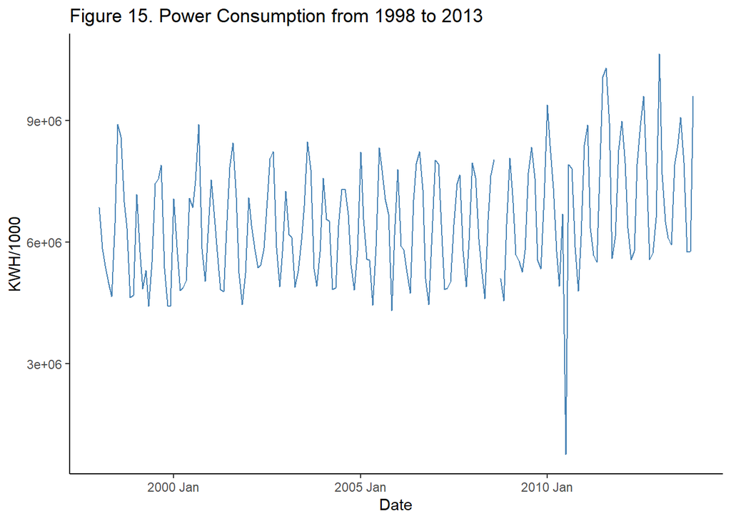

```r
load_clean%>%
  mutate(KWH = KWH)%>%
  ggplot(aes(x=Date, y=KWH))+
  geom_line(color='steelblue')+
  labs(title = 'Figure 15. Power Consumption from 1998 to 2013', y = 'KWH/1000', x='Date')+
  theme_classic()
```

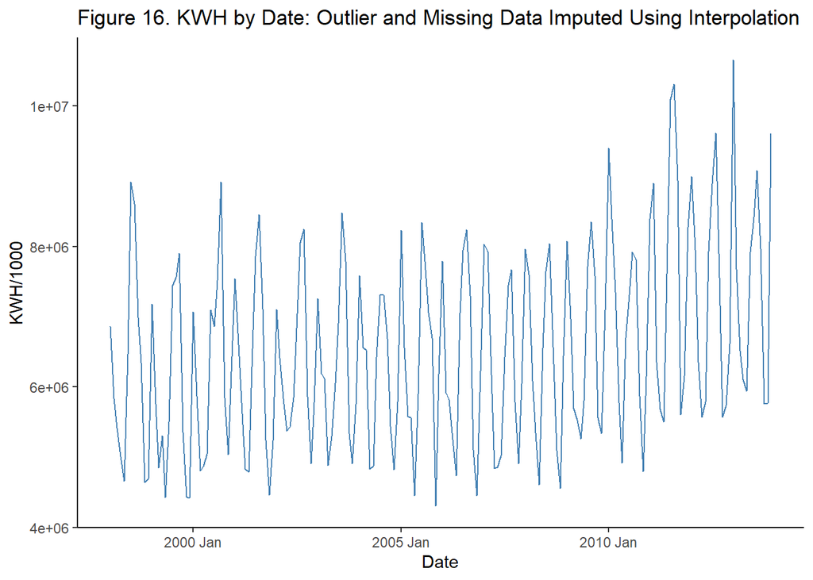

```r
# impute missing value for Sept 2008, retain outlier

load_outlier<-load_clean%>%
  na_interpolation()

# create load dataset with outlier replaced with imputed value

load_without<- load_outlier

load_without$KWH[load_without$KWH == 770523] = NA # replace outlier with NA

load_without%<>%
  na_interpolation%>%  # impute NA that has been added
  as.data.frame()%>%
  select(-CaseSequence)%>%
  as_tsibble()


# plot dataset with imputed values for missing data and single outlier

load_without%>%
  mutate(KWH = KWH)%>%
  ggplot(aes(x=Date, y=KWH))+
  geom_line(color='steelblue')+
  labs(title = 'Figure 16. KWH by Date: Outlier and Missing Data Imputed Using Interpolation', y = 'KWH/1000', x='Date')+
  theme_classic()
```

## 3.2 Autocorrelation

There are clear signs of autocorrelation in the dataset. This is reflected in a prominent 6-month lag with intervening troughs that trail by 3 months (Figure 17).

[figure not shown]

```r
load_without%>%
  ACF(KWH, lag_max=26)%>%
  autoplot()+
  labs(title='Figure 17. ACF Plot for ATM4 Time Series', x='Month', y="ACF")+
  theme_classic()
```

## 3.3 Model Training and Diagnostics

To facilitate model construction and evaluation, the dataset is split into training (80%) and test (20%) sets.

```r
# Create a training and test set

nload<-floor(nrow(load_without)*.80) # use floor to get integer value

# split data into train (80%) and test sets (20%)

train.load<- load_without[1:nload,] #   2009-05-02 to 2009-12-19
test.load<- load_without[(nload+1):nrow(load_without),] # 2009-12-20 to 2010-02-16
```

And three models (ETS, SNAIVE, ARIMA) are fit to the training data.

```r
set.seed(248)


fit.train<-train.load%>%
  model(
    ets.load = ETS(KWH ~ error('A')+trend('A')+season('A')),
    naive.load = SNAIVE(KWH ~ lag(6)),
    arima.load = ARIMA(KWH, stepwise=FALSE, approximation = FALSE)
    )
```

Comparing model results on the test predictions (Table 11: lowest RMSE and MAPE values) it is clear that the ARIMA model produces the best fit to the data.

```r
set.seed(8457)

#atm1 forecast on test set

ets.load.test<-fit.train%>%
  forecast(h=nrow(test.load))%>%
  filter(.model=='ets.load')

naive.load.test<-fit.train%>%
  forecast(h = nrow(test.load))%>%
  filter(.model=='naive.load')

arima.load.test<-fit.train%>%
  forecast(h = nrow(test.load))%>%
  filter(.model=='arima.load')

# collect measures of fit for load

etsload<-ets.load.test %>%
  accuracy(test.load)

snaiveload<-naive.load.test%>%
  accuracy(test.load)

arimaload<-arima.load.test%>%
  accuracy(test.load)

# combine models to compare fit

rbind(etsload, snaiveload, arimaload)%>%
  select(.model, RMSE, MAPE)%>%
  flextable()%>%
  set_caption('Table 11. Power (KWH) Model Fit on Test Data')
```

Table 11. Power (KWH) Model Fit on Test Data

| .model | RMSE | MAPE |
| --- | --- | --- |
| ets.load | 1,105,266 | 9.817879 |
| naive.load | 1,303,364 | 12.668011 |
| arima.load | 1,031,868 | 9.516076 |

The ARIMA model also results in residuals that are stationary, normally distributed, and absent significant signs of autocorrelation (Figure 18).

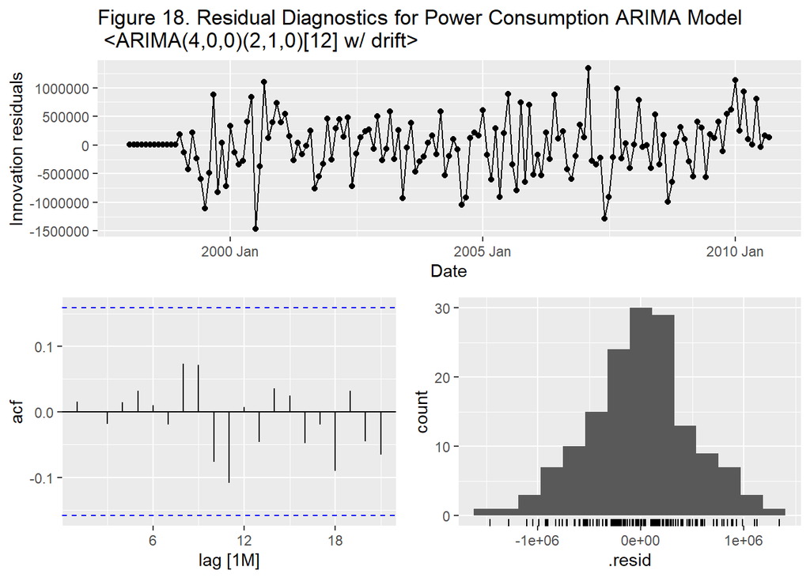

```r
#plot residuals for ARIMA model

fit.train%>%
  select(arima.load)%>%
  gg_tsresiduals()+
  labs(title='Figure 18. Residual Diagnostics for Power Consumption ARIMA Model\n <ARIMA(4,0,0)(2,1,0)[12] w/ drift>')
```

## 3.4 Final Forecast

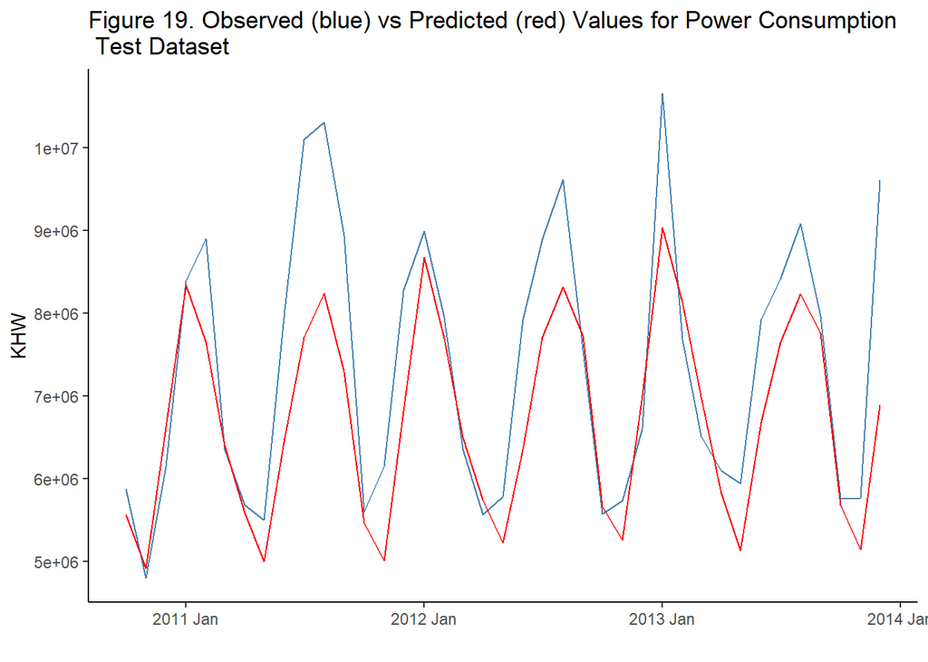

```r
# collect predictions on test data

preds<-arima.load.test%>%
  as.data.frame()%>%
  select(Date, .mean)%>%
  as_tsibble()



test.load %>%
  autoplot(series = "actuals", color='steelblue') +
  autolayer(preds, color = 'red')  +
  labs(title = "Figure 19. Observed (blue) vs Predicted (red) Values for Power Consumption\n Test Dataset", y = "KHW", x= '')+
  theme_classic()
```

And a forecast for 2014, with 80 and 95% prediction intervals, is shown in Figure 20.

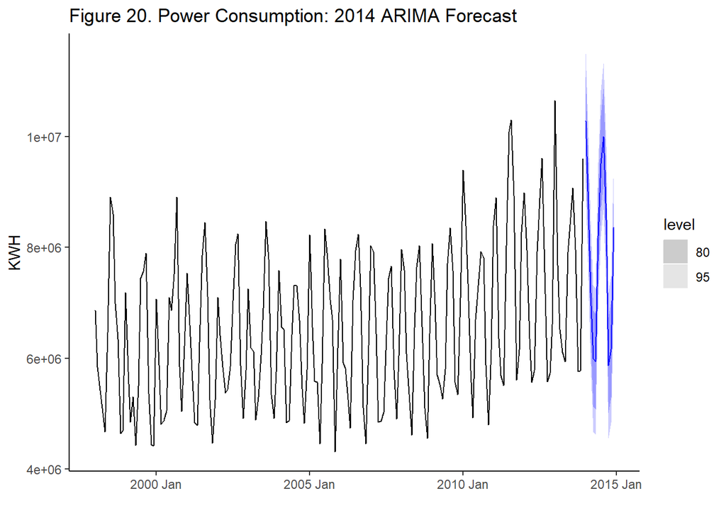

```r
set.seed(98345)

final.fit<-load_without%>%
  model(ARIMA(KWH, stepwise=FALSE, approximation = FALSE))


forecast(final.fit, h=12) %>%
  autoplot(load_without) +
  labs(title = "Figure 20. Power Consumption: 2014 ARIMA Forecast", y="KWH", x = '')+
  theme_classic()
```